# Preregistration Experimental Design and Analysis

This is the full document for the power analysis, the pre-registration of the main analysis, and the sequential analysis of the experiment on enabling control systems by Frank Ma and Stijn Masschelein.

```r
set.seed(230383)
library(tidyverse)
```

```r
library(cowplot)
ggplot2::theme_set(tint::theme_tint())
```

# Model and Parameters

## Model and Helper functions

Our model of learning over time is a relatively simple two parameter model where $M$ captures the maximimum performance and $S$ the speed of learning. $y$ is performance over time $t$.

$$y = M * (1 - e^{(-St)})$$

The following two functions allow to calculate performance and time from the other variables.

```r
calc_perf <- function(max = 100, speed = 1, time = 1:12){
  performance = max * (1 - exp(-time * speed))
}
calc_time <- function(max = 100, speed = 1, performance = 50){
  time = - (log ((max - performance)/max))/speed
}
```

## Rough effect size estimate and parameters.

The t-statistics in Hannan, Krishnan, and Newman (2008) for a similar effect as the one we expect to see in our experiment is $t = 1$ for the effect on total performance and $t = 2$ for the effect on learning (= trial 10-12 - trial 1-3). More specifically, they find that the group with fine feedback has about $9\%$ better performance and improves $3$ times as much compared to the group with no feedback in the individual incentive condition.

With some trial and error searching we found that the effect sizes are roughly equivalent to a control condition with $M = 50$ and $S = .7$ and a treatment condition of $M = 60$ and $S = .4$ for a task where the theoretical maximum performance is 100.

## Reworking the parameters

Another way to think about the speed of learning is to think about how long it takes ($t_{20}$) before performance is at 20 out of a theoretical maximum of 100.

$$M (1 - e^{-St_{20}}) = 20 \\
-ln(1 - 20/M)/S = t_{20} \\
-ln(1 - 20/M)/t_{20} = S$$

And the functions to make those calculations in `R`.

```r
calc_t20 <- function(M, S){-log(1 - 20/M) / S}
t20 <- calc_t20(60, .4)
calc_S <- function(M, t20){-log(1 - 20/M) / t20}
S <- calc_S(60, t20)
t20_1 <- calc_t20(60, .4)
t20_2 <- calc_t20(50, .7)
cat(t20_1, t20_2)
```

```
## 1.013663 0.7297509
```

# Simulation and Power

The simulation uses the parametrisation for trial20. That means that the fundamental parameter for each participant are `trial20` and `M`. It’s a ad-hoc but it allows to take into account a negative relation between M and S.

What is the maximum score of that participant

## Function

The following function runs a study with `N` participants in a control group and treatment group. Where `tM` and `tS` are the parameters for the average individual in the treatment group and `cM` and `cS` are the parameters for the average individual in the control group.

### Helper

```r
calc_diff <- function(x, t0 = 1, t1 = 3, t2 = 10, t3 = 12){
  n <- length(x)
  mean(x[t2:t3]) - mean(x[t0:t1])
}
```

### Single study

```r
run_study <- function(N = 20, tM = 60, cM = 50,
                  tS = .4, cS = .7, delay_treat = 7,
                  fixed_sd = 1, beta_curve = 2,
                  noise = FALSE, noise_param = 5){
  talpha <- beta_curve * (tM - 20)/80;
  calpha <- beta_curve * (cM - 20)/80
  treatM <- 80 * rbeta(N, talpha, beta_curve - talpha) + 20
  contrM <- 80 * rbeta(N, calpha, beta_curve - calpha) + 20
  delayM1 <- 80 * rbeta(N, calpha, beta_curve - calpha) + 20
  delayM2 <- pmin(100, delayM1 - cM + tM) # treatment

  tt20 <- calc_t20(tM, tS); ct20 <- calc_t20(cM, cS)
  tmu <- log(sqrt(tt20^4 / (fixed_sd^2 + tt20^2)))
  cmu <- log(sqrt(ct20^4 / (fixed_sd^2 + ct20^2)))
  treatt20 <- exp(rnorm(N, tmu, sqrt(2 * (log(tt20) - tmu))))
  contrt20 <- exp(rnorm(N, cmu, sqrt(2 * (log(ct20) - cmu))))
  delayt201 <- exp(rnorm(N, cmu, sqrt(2 * (log(ct20) - cmu))))
  delayt202 <- contrt20 - ct20 + tt20 # treatment
  treatS <- calc_S(treatM, treatt20)
  contrS <- calc_S(contrM, contrt20)
  delayS1 <- calc_S(delayM1, delayt201)
  delayS2 <- calc_S(delayM2, delayt202)

  treat_data <- t(mapply(calc_perf, treatM, treatS))
  contr_data <- t(mapply(calc_perf, contrM, contrS))
  treat_delay_data1 <- t(mapply(calc_perf, delayM1, delayS1,
                               list(1:(delay_treat - 1))))
  delay_eq_time <- calc_time(delayM2, delayS2,
                             treat_delay_data1[, (delay_treat - 1)])
  delay_time2 <- lapply(delay_eq_time,
    function(x){(x + 1) : (x + 1 + (12 - delay_treat))})
  treat_delay_data2 <- t(mapply(calc_perf, delayM2, delayS2,
                                delay_time2))
  if (noise){
    add_noise <- function(x) rbinom(1, noise_param, x/100)
    contr_data <- apply(contr_data, 1:2, add_noise)
    treat_data <- apply(treat_data, 1:2, add_noise)
    treat_delay_data1 <- apply(treat_delay_data1, 1:2, add_noise)
    treat_delay_data2 <- apply(treat_delay_data2, 1:2, add_noise)
  }

  return(list(
    control = contr_data, treatment = treat_data,
    delay = cbind(treat_delay_data1, treat_delay_data2),
    delay_treat = delay_treat))
}
st <- run_study(N = 20, fixed_sd = 1, beta_curve = 1, noise = T)
```

`beta_curve = 2` is close to uniform. See the appendix for more details.

### Analyse a single study

```r
analyse_study <- function(data){
  t1 <- data$delay_treat - 1; t2 <- data$delay_treat
  calc_diff_delay <- function(x){calc_diff(x, t1 = t1, t2 = t2)}
  calc_diff_delay2 <- function(x){calc_diff(x, t1 = t1,
                                            t2 = t2, t3 = 8)}
  treat_total <- apply(data$treatment, 1, sum)
  treat_diff <- apply(data$treatment, 1, calc_diff)
  contr_total <- apply(data$control, 1, sum)
  contr_diff <- apply(data$control, 1, calc_diff)
  contr_diff_delay <- apply(data$control, 1, calc_diff_delay)
  contr_diff_delay2 <- apply(data$control, 1, calc_diff_delay)
  delay_diff <- apply(data$delay, 1, calc_diff_delay)
  delay_diff2 <- apply(data$delay, 1, calc_diff_delay2)
  ttest_total <- t.test(treat_total, contr_total)
  ttest_diff <- t.test(treat_diff, contr_diff)
  ttest_diff_delay <- t.test(delay_diff, contr_diff_delay)
  ttest_diff_delay2 <- t.test(delay_diff2, contr_diff_delay2)
  return(list(ttest_total = ttest_total,
              ttest_diff = ttest_diff,
              ttest_diff_delay = ttest_diff_delay,
              ttest_diff_delay2 = ttest_diff_delay2))
}

an <- analyse_study(st)
an$ttest_diff_delay2$statistic
```

```
##       t
## 2.67013
```

## Simulation

More extensive simulations are run in the other file `simulation.Rmd` which shows more details on our trial and error process.

### Simulation function

[figure not shown]

```r
nsim <- 50
run_sim <- function(...){
  st <- run_study(...)
  an <- analyse_study(st)
  return(cbind(difft = an$ttest_diff$statistic,
               diffp = an$ttest_diff$p.value,
               totalt = an$ttest_total$statistic,
               totalp = an$ttest_total$p.value,
               delayt = an$ttest_diff_delay$statistic,
               delayp = an$ttest_diff_delay$p.value,
               delay2t = an$ttest_diff_delay2$statistic,
               delay2p = an$ttest_diff_delay2$p.value))
}
simulation <- t(drop(replicate(nsim, run_sim(
  N = 50, beta_curve = 2, delay_treat = 5, fixed_sd = 1,
  noise = TRUE, noise_param = 5))))
sim_data <- as_tibble(simulation)
xlims = c(-3,12)
diffplot <- qplot(sim_data$difft, bins = nsim/20, xlim = xlims)
totalplot <- qplot(sim_data$totalt, bins = nsim/20, xlim = xlims)
delayplot <- qplot(sim_data$delayt, bins = nsim/20, xlim = xlims)
delay2plot <- qplot(sim_data$delay2t, bins = nsim/20, xlim = xlims)
plot_grid(totalplot, diffplot, delayplot, delay2plot, ncol = 1)
power <- function(x, q){
  mean(I(x < q))
}
select(sim_data, ends_with("p")) %>%
  gather(key = "test", value = "p") %>%
  group_by(test) %>%
  summarise_all(list(power001 = function(x){power(x, 0.001)},
                     power010 = function(x){power(x, 0.01)},
                     power050 = function(x){power(x, 0.05)}))
```

```
## # A tibble: 4 x 4
##   test    power001 power010 power050
##   <chr>      <dbl>    <dbl>    <dbl>
## 1 delay2p     0.08     0.16     0.36
## 2 delayp      0.16     0.34     0.68
## 3 diffp       0.08     0.3      0.62
## 4 totalp      0        0.06     0.16
```

### Variation in the parameters not in the effect size.

```r
nsim <- 1e3
Ns <- sample(seq(20, 60, 1), size = nsim, replace = TRUE)
betas <- runif(nsim, 1, 8)
sds <- runif(nsim, .5, 2)
noise <- TRUE
noise_param <- sample(seq(5, 50, 1), size = nsim,
                      replace = TRUE)
```

### Run the simulation

```r
simulation <- vector("list", length = length(nsim))
for (i in 1:nsim){
  simulation[[i]] <- do.call(run_sim,
                             list(N = Ns[i],
                                  beta_curve = betas[i],
                                  fixed_sd = sds[i],
                                  noise = noise,
                                  noise_param = noise_param[i],
                                  delay_treat = 7)
  )
  if (i %% (nsim %/% 20) == 0) {
    cat(paste0(i, "/", nsim, " done", "\n"))}
}
```

```
## 50/1000 done
## 100/1000 done
## 150/1000 done
## 200/1000 done
## 250/1000 done
## 300/1000 done
## 350/1000 done
## 400/1000 done
## 450/1000 done
## 500/1000 done
## 550/1000 done
## 600/1000 done
## 650/1000 done
## 700/1000 done
## 750/1000 done
## 800/1000 done
## 850/1000 done
## 900/1000 done
## 950/1000 done
## 1000/1000 done
```

```r
rstudioapi::jobRunScript("run_simulation.R", importEnv = TRUE,
                         workingDir = here::here(),
                         exportEnv = "R_GlobalEnv")
```

```r
s = lapply(simulation, as.tibble)
d = bind_rows(s) %>%
  mutate(N = Ns, beta_curve = betas,
         fixed_sd = sds, noise_param = noise_param) %>%
  select(-delay2p, -delay2t) %>%
  gather(key = "statistic", value = "value",
         totalt, totalp, delayt, delayp, difft, diffp)
```

## Some Results

The graph plots the logarithm of the p-values for the tests with the parameter controlling the variability in learning speeds on the x-axis. It’s clear that at higher variability the blue dots remain at lower values but the green dots tend to cluster higher.

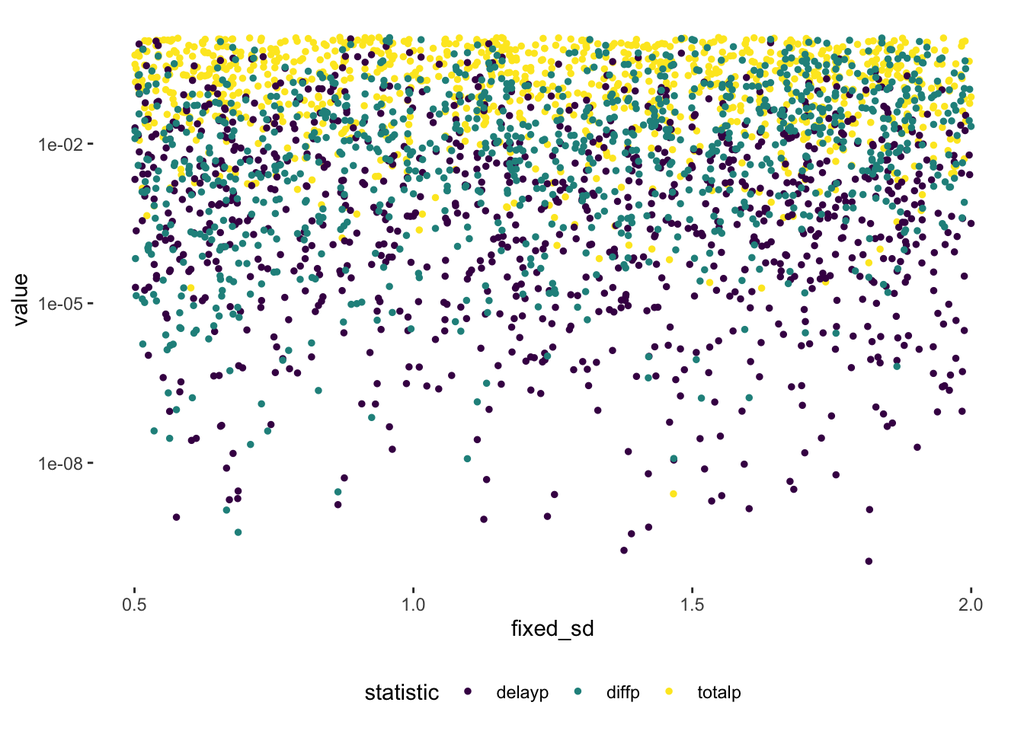

```r
ggplot(filter(d, grepl("p", statistic)),
       aes(y = value, x = fixed_sd,
           colour = statistic)) +
  geom_point(size = 1) +
  viridis::scale_colour_viridis(discrete = TRUE) +
  scale_y_log10()
```

We can also see this in the Table below where power to detect an effect at $\alpha = .001, 0.01, 0.05$ is calculated for high and low N per condition and for high and low variability in speed of learning.

```r
filter(d, grepl("p", statistic)) %>%
  group_by(I(N > 30), I(fixed_sd > 1), statistic) %>%
  summarise(p001 = mean(value < 0.001),
            p010 = mean(value < 0.010),
            p050 = mean(value < 0.050)) %>%
  kableExtra::kable(dig = 2)
```

| I(N > 30) | I(fixed_sd > 1) | statistic | p001 | p010 | p050 |
| --- | --- | --- | --- | --- | --- |
| FALSE | FALSE | delayp | 0.26 | 0.44 | 0.68 |
| FALSE | FALSE | diffp | 0.15 | 0.36 | 0.65 |
| FALSE | FALSE | totalp | 0.02 | 0.05 | 0.21 |
| FALSE | TRUE | delayp | 0.29 | 0.62 | 0.79 |
| FALSE | TRUE | diffp | 0.05 | 0.25 | 0.48 |
| FALSE | TRUE | totalp | 0.03 | 0.09 | 0.24 |
| TRUE | FALSE | delayp | 0.55 | 0.78 | 0.90 |
| TRUE | FALSE | diffp | 0.46 | 0.70 | 0.85 |
| TRUE | FALSE | totalp | 0.02 | 0.13 | 0.31 |
| TRUE | TRUE | delayp | 0.66 | 0.86 | 0.95 |
| TRUE | TRUE | diffp | 0.24 | 0.49 | 0.73 |
| TRUE | TRUE | totalp | 0.04 | 0.14 | 0.33 |

## Conclusion.

> The first conclusion we reach is that a delayed introduction of the treatment can be beneficial because it increases the power of the experimental design to detect treatment differences when there is a lot of variability in learning.

We experimented somewhat with different delays and generally *introducing the treatment halfway* through the experiment seemed to be the best option. We also experimented with shorter experiments. However, an experiment with 8 trials had a lot less power to detect the Hannan, Krishnan, and Newman (2008) effect.

> The second conconclusion is that even in scenarios with a high level of variability the delayed introduction leads to high power to detect the Hannan, Krishnan, and Newman (2008) effect with over 30 observations per condition.

We will use no more than 50 participants per condition. If an experiment with 50 participants cannot detect the effect it is likely smaller than the feedback effect in Hannan, Krishnan, and Newman (2008) and not of any economic interest.

# Alpha Spending

The power analysis shows that it is likely that we do not need 50 participants per condition to detect an effect. We use the principles of sequential analysis (Lakens 2014) and alpha spending (Demets and Lan 2014; Reboussin et al. 2000) to use a more flexible design plan.

While uncorrected p-values cannot be used to look at the intermediate data, the alpha spending approach spreads the Type I error rate over multiple looks at the data. The `ldbounds` package in `R` provides a quick implementation of the Lan-DeMets calculations.

We plan to have a first look at the data after `N = 15` in each condition and stop the data collection if the data indicate that there is less than 1 percent chance of a one-tailed Type I error in declaring a significant effect.

We use one-tailed error rates because we have directional hypotheses and use the 1 percent cut-off to guard against any deviations from the assumptions underlying the Lan-Demets algorithm.

```r
plan <- ldbounds::bounds(
  t = seq(15, 50, 5)/50, iuse = 1, alpha = 0.01)
summary(plan)
```

```
##
## Lan-DeMets bounds for a given spending function
##
## n =  8
## Overall alpha:  0.01
##
## Type: One-Sided Bounds
## alpha:  0.01
## Spending function: O'Brien-Fleming
##
## Boundaries:
##    Time   Upper    Exit pr.   Diff. pr.
## 1   0.3  4.5593  2.5662e-06  2.5662e-06
## 2   0.4  3.9135  4.6463e-05  4.3896e-05
## 3   0.5  3.4762  2.6972e-04  2.2325e-04
## 4   0.6  3.1576  8.8298e-04  6.1326e-04
## 5   0.7  2.9128  2.0790e-03  1.1960e-03
## 6   0.8  2.7172  3.9785e-03  1.8994e-03
## 7   0.9  2.5563  6.6243e-03  2.6459e-03
## 8   1.0  2.4210  1.0000e-02  3.3757e-03
```

The plan shows that if the effect has a t-statistic of $4.6$ after $N = 15$, we can stop the experiment with an expected Type I error rate of $0.01$ one-tailed.

$N = 15$ implies that $15/50 = 30\%$ of the maximum sample size has been collected. The code assumes a check every 5 participants per condition.

The cut-off values decrease as we get closer to the expected full sample of $N=50$. The attractiveness of this scheme is that it does not tie the lookups down. We can look more often or less often and recalculate the cutoffs as longs as we use the same spending function (i.e. `iuse = 1` in the `R` code).

## Preregistered Analysis

The data generation is more simple to account for the fact that the actual experiment has 6 conditions and because we want to calculate other dependent variable than the ultimate outcome.

### Participants

```r
ncond = 30
participants = tibble(
  id = 1:(6*ncond),
  internal = rep(c("yes", "no"), each = ncond * 3),
  flexibility = rep(c("yes", "yes", "no"), times = ncond * 2),
  repair = rep(c("yes", "no", "no"), times = ncond * 2)
)
```

Quick check to see whether we have the right conditions.

```r
group_by(participants, internal, flexibility, repair) %>%
  summarise(N = n()) %>%
  kableExtra::kable()
```

| internal | flexibility | repair | N |
| --- | --- | --- | --- |
| no | no | no | 30 |
| no | yes | no | 30 |
| no | yes | yes | 30 |
| yes | no | no | 30 |
| yes | yes | no | 30 |
| yes | yes | yes | 30 |

### Generate decisions.

The `generate_decisions` function creates decisions. We can turn on learning for good performance and off for bad performance. There are only two settings because this is very basic. The learning is that the participant realises that they should take the feedback about getting or not getting a payoff into account for their next decision. This allows us to generate data that explicitly shows improvements in one of the specific elements of the experimental task.

```r
nperiods = 5; ntrials = 12;
nature = sample(1:20, 12)
print(nature)
```

```
##  [1] 11  8 18 12 20 16  7 14  6 17  3  5
```

```r
generate_decision = function(learning = TRUE, p = 5, t = 12,
                             nature = 1:t){
  decision = rep(NULL, p * t)
  period = rep(NULL, p * t)
  trial = rep(NULL, p * t)
  state_of_nature = rep(NULL, p * t)
  for (i in 1:t){
  upper = 20; lower = 1;
    for (j in 1:p){
      index = j + (i - 1) * p
      decision[index] = sample(lower:upper, 1)
      period[index] = j; trial[index] = i;
      state_of_nature[index] = nature[i]
      if (learning && i > t/2){
        if(decision[index] > nature[i]){
          upper = decision[index] - 1
        } else {
          lower = decision[index]
        }
      }
    }
  }
  return(tibble(period = period, trial = trial,
                decision = decision, nature = state_of_nature))
}

decision = generate_decision(nature = nature)
head(decision) %>% kableExtra::kable()
```

| period | trial | decision | nature |
| --- | --- | --- | --- |
| 1 | 1 | 18 | 11 |
| 2 | 1 | 10 | 11 |
| 3 | 1 | 6 | 11 |
| 4 | 1 | 1 | 11 |
| 5 | 1 | 12 | 11 |
| 1 | 2 | 17 | 8 |

### Full data

```r
payoff = c(5, 5, 10, 20, 20, 30, 30, 30, 45, 45, 60, 60, 60,
           80, 80, 95, 95, 95, 100, 100)
length(payoff)
```

```
## [1] 20
```

```r
fd = mutate(
  participants,
  decision = map(internal == "yes" & flexibility == "yes",
    ~ generate_decision(learning = . , nature = nature))) %>%
  unnest(decision) %>%
  mutate(performance = if_else(decision > nature, 0, payoff[decision]))
kableExtra::kable(fd[1:8, ], )
```

| id | internal | flexibility | repair | period | trial | decision | nature | performance |
| --- | --- | --- | --- | --- | --- | --- | --- | --- |
| 1 | yes | yes | yes | 1 | 1 | 12 | 11 | 0 |
| 1 | yes | yes | yes | 2 | 1 | 19 | 11 | 0 |
| 1 | yes | yes | yes | 3 | 1 | 15 | 11 | 0 |
| 1 | yes | yes | yes | 4 | 1 | 13 | 11 | 0 |
| 1 | yes | yes | yes | 5 | 1 | 10 | 11 | 45 |
| 1 | yes | yes | yes | 1 | 2 | 4 | 8 | 20 |
| 1 | yes | yes | yes | 2 | 2 | 2 | 8 | 5 |
| 1 | yes | yes | yes | 3 | 2 | 8 | 8 | 30 |

### Results

```r
dominated = c(2, 5, 7, 8, 10, 12, 13, 15, 17, 18, 20)
fb_learning = function(periods = 1:5, decisions, performance){
  correct = 0; minimum = 1; maximum = 21;
  for (p in periods){
    d = decisions[p]
    correct = correct + (d >= minimum & d < maximum)
    if (performance[p] == 0){
      maximum = min(maximum, d)
    } else {
      minimum = max(minimum, d)
    }
  }
  return(correct/length(periods))
}
fb_learning(decisions = fd$decision[1:5],
            performance = fd$performance[1:5])
```

```
## [1] 0.4
```

```r
fb_learning(decisions = c(11, 3, 2, 6, 12),
            performance = c(0, 10, 5, 30, 0))
```

```
## [1] 0.6
```

```r
fd = mutate(fd,
            change_dominated = decision %in% dominated)

trial = group_by(fd, id, trial, internal, flexibility, repair) %>%
  summarise(fb_learning = fb_learning(period, decision, performance))
kableExtra::kable(trial[1:8, ], )
```

| id | trial | internal | flexibility | repair | fb_learning |
| --- | --- | --- | --- | --- | --- |
| 1 | 1 | yes | yes | yes | 0.4 |
| 1 | 2 | yes | yes | yes | 0.8 |
| 1 | 3 | yes | yes | yes | 0.4 |
| 1 | 4 | yes | yes | yes | 0.8 |
| 1 | 5 | yes | yes | yes | 0.6 |
| 1 | 6 | yes | yes | yes | 0.6 |
| 1 | 7 | yes | yes | yes | 1.0 |
| 1 | 8 | yes | yes | yes | 1.0 |

```r
ind = group_by(fd, id, internal, flexibility, repair) %>%
  summarise(
    average = mean(performance),
    change = mean(performance[trial > 6]) -
      mean(performance[trial < 7]),
    change_dominated = mean(dominated[trial > 6]) -
      mean(dominated[trial < 7])
  )

ind_temp = group_by(trial, id, internal, flexibility, repair) %>%
  summarise(
    change_fb_learning = mean(fb_learning[trial > 6]) -
      mean(fb_learning[trial < 7]),
  )

ind = left_join(ind, ind_temp)
print(ind)
```

```
## # A tibble: 180 x 8
## # Groups:   id, internal, flexibility [180]
##       id internal flexibility repair average change change_dominated
##    <int> <chr>    <chr>       <chr>    <dbl>  <dbl>            <dbl>
##  1     1 yes      yes         yes       26.9  -11.8               NA
##  2     2 yes      yes         no        26.7  -20.0               NA
##  3     3 yes      no          no        22.3  -22.7               NA
##  4     4 yes      yes         yes       23     -9                 NA
##  5     5 yes      yes         no        24.5  -19                 NA
##  6     6 yes      no          no        18.7  -16.3               NA
##  7     7 yes      yes         yes       27.3  -10.3               NA
##  8     8 yes      yes         no        18.5  -14.7               NA
##  9     9 yes      no          no        17.8  -11.5               NA
## 10    10 yes      yes         yes       30.2  -16.2               NA
## # … with 170 more rows, and 1 more variable: change_fb_learning <dbl>
```

```r
skimr::skim_with(numeric = list(mean = mean, sd = sd, N = length),
          append = FALSE)
group_by(ind, internal, flexibility, repair) %>%
  skimr::skim(average)
```

```
## Skim summary statistics
##  n obs: 180
##  n variables: 8
##  group variables: internal, flexibility, repair
##
## ── Variable type:numeric ───────────────────────────────────────────────────────────────────────────────────────────────
##  internal flexibility repair variable  mean   sd  N
##        no          no     no  average 20.64 2.06 30
##        no         yes     no  average 21.16 2.98 30
##        no         yes    yes  average 20.89 2.87 30
##       yes          no     no  average 21.39 2.43 30
##       yes         yes     no  average 24.51 2.91 30
##       yes         yes    yes  average 24.02 3.32 30
```

```r
group_by(ind, internal, flexibility, repair) %>%
  skimr::skim(change)
```

```
## Skim summary statistics
##  n obs: 180
##  n variables: 8
##  group variables: internal, flexibility, repair
##
## ── Variable type:numeric ───────────────────────────────────────────────────────────────────────────────────────────────
##  internal flexibility repair variable   mean   sd  N
##        no          no     no   change -15.86 7.19 30
##        no         yes     no   change -16.66 4.86 30
##        no         yes    yes   change -16.84 5.98 30
##       yes          no     no   change -16.22 5.87 30
##       yes         yes     no   change -10.68 5.2  30
##       yes         yes    yes   change -10.61 5.39 30
```

### Descriptive Plot

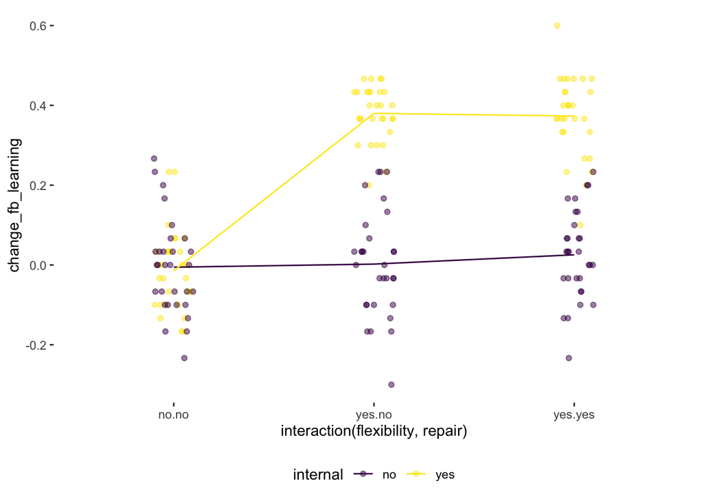

```r
plot <- ggplot(ind, aes(x = interaction(flexibility, repair),
                        y = change_fb_learning,
                        # group = interaction(flexibility, repair),
                        group = internal,
                        colour = internal)) +
  geom_jitter(alpha = .5, width = .1) +
  stat_summary(fun.y = "mean", geom = "line") +
  viridis::scale_colour_viridis(discrete = TRUE)
print(plot)
```

> The main analysis below will be performed on four variables as defined above. The variables are
1. The change in performance (`change`)
2. The change in the number of dominated choices (`change_dominated`)
3. The change in the number of wrong choices give the performance feedback (`change_fb_learning`).
4. The change in the number of optimal choices. This code for this variable still needs to be written.

### Main Analysis

We are interested in two interaction effects internal x flexibility and internal x repair.

```r
d = ungroup(ind) %>%
  select(internal, flexibility, repair, change) %>%
  mutate(
    main_internal = if_else(internal == "yes", 1, -1),
    main_flexibility_repair = if_else(flexibility == "yes", 0.5, -1),
    main_repair = case_when(
      flexibility == "no" ~ 0,
      flexibility == repair ~ 1,
      flexibility != repair ~ -1),
    internal_flexibility = case_when(
      repair == "yes" ~ 0,
      internal != flexibility ~ -1,
      internal == flexibility ~ 1),
    internal_repair = case_when(
      repair == "no" & flexibility == "yes" ~ 0,
      internal != repair ~ -1,
      internal == repair ~ 1)
  )
group_by(d, internal, flexibility, repair) %>%
  summarise_all(mean) %>%
  kableExtra::kable()
```

| internal | flexibility | repair | change | main_internal | main_flexibility_repair | main_repair | internal_flexibility | internal_repair |
| --- | --- | --- | --- | --- | --- | --- | --- | --- |
| no | no | no | -15.86111 | -1 | -1.0 | 0 | 1 | 1 |
| no | yes | no | -16.66111 | -1 | 0.5 | -1 | -1 | 0 |
| no | yes | yes | -16.83889 | -1 | 0.5 | 1 | 0 | -1 |
| yes | no | no | -16.21667 | 1 | -1.0 | 0 | -1 | -1 |
| yes | yes | no | -10.68333 | 1 | 0.5 | -1 | 1 | 0 |
| yes | yes | yes | -10.60556 | 1 | 0.5 | 1 | 0 | 1 |

```r
reg = lm(
  change ~ main_internal + main_flexibility_repair +
    main_repair + internal_flexibility + internal_repair,
  data = d)
```

We apply the nearly exact adjustement proposed by Young (2016) to have better estimates of the variance covariance matrix. The adjustment is similar to the Satterthwaite and Welch adjustments and can be intepreted as a more general version of the Welch ANOVA and Welch t-test for unequal variances.

The code for the adjustment can be found in the Appendix.

```r
reg_exact = lm_nearly(
  change ~ main_internal + main_flexibility_repair +
    main_repair + internal_flexibility + internal_repair,
  data = d)
kableExtra::kable(reg_exact$coefficients, dig = 3)
```

| variable | estimate | se | t value | df | p value |
| --- | --- | --- | --- | --- | --- |
| (Intercept) | -14.478 | 0.433 | -33.408 | 174 | 0.000 |
| main_internal | 1.976 | 0.433 | 4.560 | 174 | 0.000 |
| main_flexibility_repair | 1.561 | 0.655 | 2.385 | 116 | 0.019 |
| main_repair | -0.025 | 0.492 | -0.051 | 116 | 0.960 |
| internal_flexibility | 1.013 | 0.574 | 1.765 | 116 | 0.080 |
| internal_repair | 1.141 | 0.607 | 1.878 | 116 | 0.063 |

> The t-statistic calculated for `internal_flexibility` and `internal_repair` will be monitored to assess whether the data collection can be stopped.

# Appendix

## Beta distribution

The beta distribution $B(\alpha, \beta)$ stays between 0 and 1. The mean is given by $\frac{\alpha}{\alpha + \beta}$ and the variance is given by $\frac{\alpha \beta}{(\alpha+\beta)^{2}(\alpha+\beta+1)}$

$$M = \frac{\alpha}{\alpha + \beta} \\
V = \frac{\alpha \beta}{(\alpha+\beta)^{2}(\alpha+\beta+1)}$$

If we set $\alpha = 4 - \beta$.
$$M = \frac{\alpha}{4}
V = \frac{4 \alpha - \alpha^2}{80} \\
\sigma = \sqrt{\frac{4\alpha - \alpha^2}{80}}\\$$

```r
alpha = seq(0, 4, length.out = 21)
round(sqrt((4 * alpha - alpha^2) / (16 * 5)), 2)
```

```
##  [1] 0.00 0.10 0.13 0.16 0.18 0.19 0.20 0.21 0.22 0.22 0.22 0.22 0.22 0.21
## [15] 0.20 0.19 0.18 0.16 0.13 0.10 0.00
```

The difference in standard deviations is not going to be too big as long as we are not too close to 4 or 0 for $\alpha$.

## log normal

The log normal distribution is always positive which makes it a good distribution to generate simulated speed. A $lognormal(\mu,\sigma)$ has an expected value of $exp(\mu + \frac{\sigma^2}{2})$ and a variance of $\left[\exp \left(\sigma^{2}\right)-1\right] \exp \left(2 \mu+\sigma^{2}\right)$

$$\begin{aligned}
M &= \exp(\mu + \frac{\sigma^2}{2})
&V &= \left[\exp \left(\sigma^{2}\right)-1\right] \exp \left(2 \mu+\sigma^{2}\right) \\
2(\ln(M) - \mu) &= \sigma^2 \\
M^2 &= exp(2\mu + \sigma^2) & V &=
\left[\exp^2(\ln(M) - \mu) - 1 \right] M^2 \\
& &V &= \frac{M^4}{\exp^2(\mu)} - M^2
\end{aligned}$$

## Nearly Exact Covariances.

```r
#' Install the sandwich package if necessary
if (!require("sandwich")) install.packages("sandwich")

#' Calculate the nearly exact bias and edf for the HC1 Variance
#' Estimator.
#' @param x design matrix of the regression
#' @param w hypothesis test
nearly_exact <- function(x, w){
  N = nrow(x); k = ncol(x) - 1; c = N / (N - k);
  xx <- solve(crossprod(x))
  M = diag(rep(1, N)) - tcrossprod(x %*% xx, x)
  z = tcrossprod(t(w) %*% xx, x); zz = z %*% t(z); z2 = z^2;
  mu = c/zz * sum(z^2 * diag(M))
  nu = 2 * c^2 / zz^2 * (tcrossprod(z2 %*% M^2, z2))
  edf = 2 * mu^2 / nu
  return(list(mu = as.numeric(mu), edf = as.numeric(edf)))
}

#' Calculate the coefficient table for the nearly
#' exact bias and df correction.
#' @param formula The regression formula as would be used with lm
#' @param data A dataframe
#' @param pdigits Number of digits to round the p-value

lm_nearly <- function(formula, data, pdigits = 4){
  reg <- lm(formula = formula, data = data)
  x <- model.matrix(object = formula, data = data)
  covHC <- sandwich::vcovHC(x = reg, type = "HC1")
  seHC <- sqrt(diag(covHC)); varnames <- names(seHC);
  coefficients <- data.frame(matrix(nrow = length(varnames), ncol = 6))
  names(coefficients) <- c("variable", "estimate", "se",
                           "t value", "df", "p value")
  coefficients$variable <- varnames
  for (var in varnames){
    hypothesis = I(varnames == var)
    correction <- nearly_exact(x = x, w = hypothesis)
    se = seHC[var] / sqrt(correction$mu)
    stat <- reg$coefficients[var]/se
    coefficients[coefficients$variable == var, 2:6] <- c(
      reg$coefficients[var], se, stat, correction$edf,
      round(2 * pt(abs(stat), correction$edf, lower.tail = FALSE),
            pdigits)
    )
  }
  return(list(coefficients = coefficients, lm = reg))
}

#' Useage

corrected <- lm_nearly(speed ~ dist, cars)
print(corrected$coefficients, digits = 2)
```

[output not shown]

# References

Demets, David L., and K.K. Lan Gordon. 2014. “Alpha-Spending Function.” In *Methods and Applications of Statistics in Clinical Trials*, 1:53, 64. wiley.

Hannan, R. Lynn, Ranjani Krishnan, and Andrew H. Newman. 2008. “The Effects of Disseminating Relative Performance Feedback in Tournament and Individual Performance Compensation Plans.” *The Accounting Review* 83 (4): 893–913. https://doi.org/10.2308/accr.2008.83.4.893.

Lakens, Daniël. 2014. “Performing High-Powered Studies Efficiently with Sequential Analyses.” *European Journal of Social Psychology* 44 (7): 701–10. https://doi.org/10.1002/ejsp.2023.

Reboussin, D. M., D. L. DeMets, K. M. Kim, and K. K. Lan. 2000. “Computations for Group Sequential Boundaries Using the Lan-DeMets Spending Function Method.” *Controlled Clinical Trials* 21 (3): 190–207.

Young, Alwyn. 2016. “Improved, Nearly Exact, Statistical Inference with Robust and Clustered Covariance Matrices Using Effective Degrees of Freedom Corrections.”